# The Interactive Effects of Ambivalence and Certainty on Political Opinion Stability: Analyses

Luttrell, Petty, & Brinol

# Set Up Workspace

```r
source("setup.R")
```

# Data

These data are not ours to share and can be accessed via the Interuniversity Consortium for Political and Social Research (ICPSR): https://doi.org/10.3886/ICPSR03435.v1

The following analyses are meant to be reproducible with the raw data as provided by the ICPSR.

```r
df <- read_csv("FloridaVoters1999_RAW.csv")
```

# Method

## Participants

Sample Size: `nrow(df)` = 708

### Age

```r
df$Age <- df$AGE_D3
df$Age[df$Age == 200] <- NA #Missing age data coded as 200
summarize(df, Mean.Age = round(mean(Age, na.rm = T), 2),
          SD.Age = round(sd(Age, na.rm = T), 2)) %>% kable() %>%
  kable_styling(bootstrap_options = c("hover", "condensed", "responsive"),
                full_width = F, position = "center")
```

| Mean.Age | SD.Age |
| --- | --- |
| 60.1 | 15.58 |

Missing data: *n* = 7

“Don’t Know”: *n* = 18

### Gender

VAR: GEND_D9

“Gender”

1. Female
2. Male

```r
df <- mutate(df, Gender = factor(GEND_D9, labels = c("Female", "Male")),
             Gender.dum = case_when(Gender == "Female" ~ 0,
                                    Gender == "Male" ~ 1))
table(df$Gender, useNA = "ifany") %>% prop.table() %>% round(3) %>%
  as.data.frame() %>% dplyr::rename(Proportion = Freq) %>% kable() %>%
  kable_styling(bootstrap_options = c("hover", "condensed", "responsive"),
                full_width = F, position = "center")
```

| Var1 | Proportion |
| --- | --- |
| Female | 0.538 |
| Male | 0.460 |
| NA | 0.001 |

Missing data: *n* = 1

### Education

“How many years of schooling have you had?”

200 = “Don’t know”

```r
df$Education <- df$SKOOL_D2
df$Education[df$Education == 200]  <- NA
summarize(df, Mean.Education = round(mean(Education, na.rm = T), 2),
          SD.Education = round(sd(Education, na.rm = T), 2)) %>% kable() %>%
  kable_styling(bootstrap_options = c("hover", "condensed", "responsive"),
                full_width = F, position = "center")
```

| Mean.Education | SD.Education |
| --- | --- |
| 14.13 | 2.65 |

Missing cases: *n* = 7

“Don’t Know”: *n* = 6

### Ideology

VAR: SCALE_26

“We hear a lot of talk these days about liberals and conservatives. On a scale of ONE through SEVEN, where”1" is very liberal, and “7” is very conservative, where would you place yourself on this scale?"

```r
df$Ideology <- df$SCALE_26
df$Ideology[df$Ideology == 9] <- NA
summarize(df, Mean.Ideology = round(mean(Ideology, na.rm = T), 2),
          SD.Ideology = round(sd(Ideology, na.rm = T), 2)) %>% kable() %>%
  kable_styling(bootstrap_options = c("hover", "condensed", "responsive"),
                full_width = F, position = "center")
```

| Mean.Ideology | SD.Ideology |
| --- | --- |
| 4.53 | 1.61 |

Missing cases: *n* = 6

“Don’t Know”: *n* = 26

## Measures

### Attitude Stability

For simplicity, we recoded `ABORT_9` and `ABORT2_9` as “att1” and “att2”

```r
df$att1 <- df$ABORT_9
df$att2 <- df$ABORT2_9
```

Number refusing either attitude question (coded as “5”):

`sum(df$att1 == 5 | df$att2 == 5) =` 9

```r
df$att1[df$att1 == 5] <- NA #Taking "refusals" and coding as missing
df$att2[df$att2 == 5] <- NA #Taking "refusals" and coding as missing
```

#### Dichotomous Change

Coding attitude change as basic change/no-change dichotomy:

```r
df <- df %>% mutate(change.F = factor(att1 == att2, labels = c("Changed", "Didn't Change")), #Change as labeled factor
                    change = abs(as.numeric(change.F) - 2)) #Dummy code change

select(df, att1, att2, change.F, change) %>% sample_n(6)
```

| att1 | att2 | change.F | change |
| --- | --- | --- | --- |
| 2 | NA | NA | NA |
| 1 | 1 | Didn’t Change | 0 |
| 1 | 1 | Didn’t Change | 0 |
| 2 | NA | NA | NA |
| 1 | NA | NA | NA |
| 1 | 1 | Didn’t Change | 0 |

Breakdown of change/no-change…

Absolute numbers:

```r
table(df$change.F)
```

| Changed | Didn’t Change |
| --- | --- |
| 104 | 314 |

Proportion:

```r
table(df$change.F) %>% prop.table() %>% round(2)
```

| Changed | Didn’t Change |
| --- | --- |
| 0.25 | 0.75 |

#### Unique Type of Change

Coding for all types of change (and stability)

```r
df$changeFull <- 99
df$changeFull[df$att1 == 1 & df$att2 == 1] <- 1
df$changeFull[df$att1 == 1 & df$att2 == 2] <- 2
df$changeFull[df$att1 == 1 & df$att2 == 3] <- 3
df$changeFull[df$att1 == 1 & df$att2 == 4] <- 4
df$changeFull[df$att1 == 2 & df$att2 == 1] <- 5
df$changeFull[df$att1 == 2 & df$att2 == 2] <- 6
df$changeFull[df$att1 == 2 & df$att2 == 3] <- 7
df$changeFull[df$att1 == 2 & df$att2 == 4] <- 8
df$changeFull[df$att1 == 3 & df$att2 == 1] <- 9
df$changeFull[df$att1 == 3 & df$att2 == 2] <- 10
df$changeFull[df$att1 == 3 & df$att2 == 3] <- 11
df$changeFull[df$att1 == 3 & df$att2 == 4] <- 12
df$changeFull[df$att1 == 4 & df$att2 == 1] <- 13
df$changeFull[df$att1 == 4 & df$att2 == 2] <- 14
df$changeFull[df$att1 == 4 & df$att2 == 3] <- 15
df$changeFull[df$att1 == 4 & df$att2 == 4] <- 16

df <- mutate(df, changeFull.F = factor(changeFull, labels = c('Pro-Choice -> Pro-Choice',
                                                             'Pro-Choice -> Pro-Life',
                                                             'Pro-Choice -> Neither',
                                                             'Pro-Choice -> DK',
                                                             'Pro-Life -> Pro-Choice',
                                                             'Pro-Life -> Pro-Life',
                                                             'Pro-Life -> Neither',
                                                             'Pro-Life -> DK',
                                                             'Neither -> Pro-Choice',
                                                             'Neither -> Pro-Life',
                                                             'Neither -> Neither',
                                                             'Neither -> DK',
                                                             'DK -> Pro-Choice',
                                                             'DK -> Pro-Life',
                                                             'DK -> Neither',
                                                             'DK -> DK',
                                                             'No Time 2 Attitude')))
```

**Table 1**

```r
df %>% filter(changeFull < 99) %>%
  group_by(changeFull.F) %>%
  summarise(n = n()) %>%
  mutate(prop = round(100*(n / sum(n)), 1))  %>% kable() %>%
  kable_styling(bootstrap_options = c("hover", "condensed", "responsive"),
                full_width = F, position = "center")
```

| changeFull.F | n | prop |
| --- | --- | --- |
| Pro-Choice -> Pro-Choice | 181 | 43.3 |
| Pro-Choice -> Pro-Life | 19 | 4.5 |
| Pro-Choice -> Neither | 16 | 3.8 |
| Pro-Choice -> DK | 6 | 1.4 |
| Pro-Life -> Pro-Choice | 22 | 5.3 |
| Pro-Life -> Pro-Life | 123 | 29.4 |
| Pro-Life -> Neither | 8 | 1.9 |
| Pro-Life -> DK | 2 | 0.5 |
| Neither -> Pro-Choice | 13 | 3.1 |
| Neither -> Pro-Life | 6 | 1.4 |
| Neither -> Neither | 8 | 1.9 |
| Neither -> DK | 1 | 0.2 |
| DK -> Pro-Choice | 2 | 0.5 |
| DK -> Pro-Life | 5 | 1.2 |
| DK -> Neither | 4 | 1.0 |
| DK -> DK | 2 | 0.5 |

Number of people changing between “pro” and “anti”:

```r
sum(df$changeFull == 2 | df$changeFull == 5)
```

```
## [1] 41
```

### Ambivalence

#### “Mixed”

VAR: ISSB_25b

“I sometimes have mixed feelings and beliefs about the abortion issue.”

1. Strongly agree
2. Somewhat agree
3. Somewhat disagree
4. Strongly disagree
5. Neither agree/disagree
6. Don’t know

For simplicity, renmaing variable `ISSB_25B` to “mixed”.

```r
df$mixed <- df$ISSB_25B
```

Number of “don’t know” responses:

```r
sum(df$mixed == 6, na.rm = T)
```

```
## [1] 30
```

Dropping “don’t know” responses and recoding remaining responses to reflect a linear Likert scale:

```r
df$mixed[df$mixed == 6] <- NA
df$mixed <- recode(df$mixed, '1' = '5', '2' = '4', '3' = '2', '4' = '1', '5' = '3') %>% as.numeric()
```

#### Conflicted

VAR: TORN_10a

Responses rated “on a 7-point scale to indicate how similar or dissimilar the statement is to your own feelings about abortion. Using a scale of ONE through SEVEN, where ‘ONE’ means the statement is very similar to your own feelings and ‘SEVEN’ means it is not like your own feelings at all, where would you place yourself on the following statement…”

“I sometimes find myself feeling ‘torn’ between two sides of the abortion issue.”

1. Very similar to own feelings
7. Not like own feelings at all
8. Do not know
9. Refused

For simplicity, renmaing variable `TORN_10a` to “torn”.

```r
df$torn <- df$TORN_10A
```

Number of “don’t know” responses:

```r
sum(df$torn == 8, na.rm = T)
```

```
## [1] 18
```

Dropping “don’t know” and “refused” responses and recoding remaining responses so that higher values correspond with greater felt conflict:

```r
df$torn[df$torn == 8] <- NA #dropping DKs
df$torn[df$torn == 9] <- NA #dropping refusals
df$torn <- 8 - df$torn #Reverse score so higher numbers = higher ambivalence
```

### Certainty

VAR: ISSA_25A

“I think my views about abortion are absolutely correct.”

1. Strongly agree
2. Somewhat agree
3. Somewhat disagree
4. Strongly disagree
5. Neither agree/disagree
6. Don’t know

For simplicity, renaming variable `ISA2_25a` to “cert”.

```r
df$cert <- df$ISSA_25A
```

Number of “don’t know” responses:

```r
sum(df$cert == 6, na.rm = T)
```

```
## [1] 42
```

Dropping “don’t know” responses and recoding remaining responses to reflect a linear Likert scale:

```r
df$cert[df$cert == 6] <- NA
df$cert <- recode(df$cert, '1' = '5', '2' = '4', '3' = '2', '4' = '1', '5' = '3') %>% as.numeric()
```

# Results

## Predicting retention

Retention is defined here as recorded response (including refusal) for Wave 2 abortion attitudes. This definition serves the study’s purpose and matches the survey document’s reported number of participants completing Wave 2.

```r
df$retention <- factor(!is.na(df$ABORT2_9), labels = c("Dropped Out", "Answered T2"))
table(df$retention)
```

| Dropped Out | Answered T2 |
| --- | --- |
| 282 | 426 |

Logistic regression predicting retention:

```r
df$att.F <- factor(df$att1, labels = c("Pro-Choice", "Pro-life", "Neither", "Don't Know"))
glm(retention ~ Age + Gender.dum + Education + Ideology + mixed + cert + torn + att.F, family = "binomial", df) %>% display.glm() %>% kable.lm()
```

| term | B | SE | Z | df | p.value | conf.low | conf.high |  |
| --- | --- | --- | --- | --- | --- | --- | --- | --- |
| (Intercept) | 0.98 | 0.77 | 1.27 | 582 | 0.204 | -0.52 | 2.50 |  |
| Age | -0.01 | 0.01 | -1.14 | 582 | 0.254 | -0.02 | 0.00 |  |
| Gender.dum | -0.13 | 0.17 | -0.73 | 582 | 0.463 | -0.46 | 0.21 |  |
| Education | 0.02 | 0.03 | 0.53 | 582 | 0.594 | -0.05 | 0.08 |  |
| Ideology | 0.01 | 0.06 | 0.09 | 582 | 0.928 | -0.11 | 0.12 |  |
| mixed | 0.00 | 0.06 | -0.01 | 582 | 0.989 | -0.12 | 0.12 |  |
| cert | -0.06 | 0.07 | -0.83 | 582 | 0.407 | -0.20 | 0.08 |  |
| torn | -0.04 | 0.04 | -1.02 | 582 | 0.31 | -0.11 | 0.04 |  |
| att.FPro-life | 0.03 | 0.20 | 0.17 | 582 | 0.868 | -0.35 | 0.42 |  |
| att.FNeither | 0.07 | 0.36 | 0.20 | 582 | 0.844 | -0.62 | 0.79 |  |
| att.FDon’t Know | -0.45 | 0.63 | -0.71 | 582 | 0.478 | -1.73 | 0.80 |  |

## Certainty and “Mixed” Predicting Response Instability

### Table 2

```r
df.sub <- filter(df, !is.na(change))
df.sub %>% select(cert, mixed, torn, Age, Education, Ideology) %>%
  psych::describe() %>% select(mean, sd) %>% round(2) %>% kable() %>%
  kable_styling(bootstrap_options = c("hover", "condensed", "responsive"),
                full_width = F, position = "center")
```

|  | mean | sd |
| --- | --- | --- |
| cert | 3.88 | 1.32 |
| mixed | 2.93 | 1.64 |
| torn | 3.40 | 2.61 |
| Age | 59.47 | 15.65 |
| Education | 14.16 | 2.58 |
| Ideology | 4.54 | 1.66 |

```r
select(df.sub, cert, mixed, torn, Age, Education, Ideology) %>% corstars() %>%
  kable() %>%
  kable_styling(bootstrap_options = c("hover", "condensed", "responsive"),
                full_width = F, position = "center")
```

|  | cert | mixed | torn | Age | Education |
| --- | --- | --- | --- | --- | --- |
| cert |  |  |  |  |  |
| mixed | -0.34*** |  |  |  |  |
| torn | -0.23*** | 0.46*** |  |  |  |
| Age | -0.02 | 0.00 | 0.03 |  |  |
| Education | -0.07 | -0.01 | 0.07 | -0.13** |  |
| Ideology | 0.13* | -0.07 | -0.12* | 0.03 | -0.05 |

**Only Those Who Completed Both Waves**

- Certainty and Mixed: $r = -.34$, 95% CI $[-.43$, $-.25]$, $t(380) = -7.16$, $p < .001$
- Certainty and Torn: $r = -.23$, 95% CI $[-.33$, $-.13]$, $t(371) = -4.62$, $p < .001$
- Mixed and Torn: $r = .46$, 95% CI $[.38$, $.54]$, $t(378) = 10.13$, $p < .001$

**Full Sample**

- Certainty and Mixed: $r = -.33$, 95% CI $[-.40$, $-.26]$, $t(640) = -8.85$, $p < .001$
- Certainty and Torn: $r = -.24$, 95% CI $[-.32$, $-.17]$, $t(624) = -6.28$, $p < .001$
- Mixed and Torn: $r = .48$, 95% CI $[.42$, $.54]$, $t(634) = 13.84$, $p < .001$

### Effects on Any Change

(Note: `df.sub` is used as the dataframe for these analyses because it restricts data to only to those who completed both waves.)

*First, centering predictors:*

```r
df.sub <- df.sub %>%
  mutate(mixed.c = mixed - mean(mixed, na.rm = T),
         torn.c = torn - mean(torn, na.rm = T),
         cert.c = cert - mean(cert, na.rm = T))
```

```r
model1 <- glm(change ~ Age + Gender.dum + Education + Ideology + mixed.c * cert.c, family = "binomial", df.sub)
display.glm(model1) %>% kable.lm()
```

term

B

SE

Z

df

p.value

conf.low

conf.high

(Intercept)

-0.65

1.01

-0.64

360

0.522

-2.65

1.33

Age

0.01

0.01

1.50

360

0.133

0.00

0.03

Gender.dum

0.28

0.25

1.12

360

0.262

-0.21

0.78

Education

-0.10

0.05

-1.94

360

0.052

-0.20

0.00

.

Ideology

0.01

0.08

0.13

360

0.893

-0.14

0.17

mixed.c

0.26

0.08

3.10

360

0.002

0.10

0.43

cert.c

-0.13

0.10

-1.25

360

0.21

-0.32

0.07

mixed.c:cert.c

0.15

0.06

2.46

360

0.014

0.03

0.27

(Model estimated from *N* = 368; 50 omitted due to missing data.)

#### Decomposing Interaction

```r
df.sub <- df.sub %>%
  mutate(mixed_low = mixed - mean(mixed, na.rm = T) + sd(mixed, na.rm = T),
         mixed_high = mixed - mean(mixed, na.rm = T) - sd(mixed, na.rm = T),
         cert_low = cert - mean(cert, na.rm = T) + sd(cert, na.rm = T),
         cert_high = cert - 5)
```

**Effect of Certainty at Low Ambivalence:**

```r
glm(change ~ Age + Gender.dum + Education + Ideology + mixed_low * cert, family = "binomial", df.sub) %>% display.glm() %>% filter(term == "cert") %>% kable.lm()
```

term

B

SE

Z

df

p.value

conf.low

conf.high

cert

-0.37

0.16

-2.29

360

0.022

-0.68

-0.05

**Effect of Certainty at High Ambivalence:**

```r
glm(change ~ Age + Gender.dum + Education + Ideology + mixed_high * cert, family = "binomial", df.sub) %>% display.glm() %>% filter(term == "cert") %>% kable.lm()
```

| term | B | SE | Z | df | p.value | conf.low | conf.high |  |
| --- | --- | --- | --- | --- | --- | --- | --- | --- |
| cert | 0.12 | 0.12 | 0.98 | 360 | 0.326 | -0.11 | 0.35 |  |

**Effect of Ambivalence at Low Certainty:**

```r
glm(change ~ Age + Gender.dum + Education + Ideology + mixed * cert_low, family = "binomial", df.sub) %>% display.glm() %>% filter(term == "mixed") %>% kable.lm()
```

| term | B | SE | Z | df | p.value | conf.low | conf.high |  |
| --- | --- | --- | --- | --- | --- | --- | --- | --- |
| mixed | 0.07 | 0.12 | 0.57 | 360 | 0.571 | -0.16 | 0.3 |  |

**Effect of Ambivalence at High Certainty:**

```r
glm(change ~ Age + Gender.dum + Education + Ideology + mixed * cert_high, family = "binomial", df.sub) %>% display.glm() %>% filter(term == "mixed") %>% kable.lm()
```

| term | B | SE | Z | df | p.value | conf.low | conf.high |  |
| --- | --- | --- | --- | --- | --- | --- | --- | --- |
| mixed | 0.43 | 0.11 | 3.98 | 360 | < .001 | 0.22 | 0.64 | *** |

#### Figure 1

```r
int.plot <- ggeffect(glm(change ~ Age + Gender.dum + Education + Ideology + mixed * cert, family = "binomial", df),
         terms = c("cert", "mixed [meansd]")) %>%
  mutate(mixed = factor(group, labels = c("Low Ambivalence (-1 SD)   ",
                                          "Average Ambivalence",
                                          "High Ambivalence (+1 SD)"))) %>%
  filter(mixed != "Average Ambivalence") %>%
  #filter(x == 1 | x == 5) %>%
  ggplot(aes(x = x, y = predicted, linetype = mixed)) +
  annotate(geom = "rect", xmin = min(df$cert, na.rm = T),
           xmax = mean(df$cert, na.rm = T) - sd(df$cert, na.rm = T),
           ymin = 0, ymax = .5, fill = "grey", alpha = 0.25) +
  geom_line(size = 2) +
  apatheme +
  labs(y = "Probability of Response Change",
       x = "Certainty",
       linetype = "") +
  scale_linetype_manual(values = c("dashed", "solid")) +
  guides(fill = F, color = F,
         linetype = guide_legend(keywidth = 0.75, default.unit = "inch")) +
  theme(legend.position = "top",
        text = element_text(size = 14, family = "Book Antiqua"),
        axis.title.x = element_text(size = 16),
        axis.title.y = element_text(size = 16),
        legend.text = element_text(size = 15)) +
  ylim(c(0,0.5))
```

```
## Package `effects` is not available, but needed for `ggeffect()`. Either install package `effects`, or use `ggpredict()`. Calling `ggpredict()` now.FALSE
```

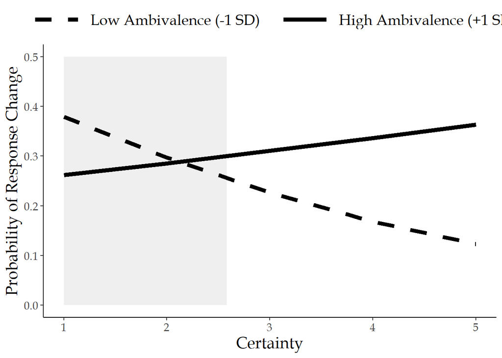

```r
print(int.plot)
```

```r
ggsave(plot = int.plot, "Fig1.png", type = "cairo-png", dpi = 600, width = 8, height = 5, units = "in") #Save graph
```

### Effects on Pro-Anti Change

Coding for ‘strict’ change:

```r
df$change_strict <- NA
df$change_strict[df$changeFull == 2 | df$changeFull == 5] <- 1 #Pro-Choice -> Pro-Life OR Pro-Life -> Pro-Choice
df$change_strict[df$changeFull == 1 | df$changeFull == 6] <- 0 #Stays Pro-Choice OR Stays Pro-Life
```

Reducing data only to those showing “strict” change:

```r
df.strict <- df %>% filter(!is.na(change_strict)) %>%
  mutate(mixed.c = mixed - mean(mixed, na.rm = T),
         torn.c = torn - mean(torn, na.rm = T),
         cert.c = cert - mean(cert, na.rm = T),
         mixed_low = mixed - mean(mixed, na.rm = T) + sd(mixed, na.rm = T),
         mixed_high = mixed - mean(mixed, na.rm = T) - sd(mixed, na.rm = T),
         cert_low = cert - mean(cert, na.rm = T) + sd(cert, na.rm = T),
         cert_high = cert - 5)
```

Degree of ‘strict’ change:

```r
df.strict %>%
  group_by(change_strict) %>%
  summarise(n = n()) %>%
  mutate(prop = round(100*(n / sum(n)), 1))  %>% kable() %>%
  kable_styling(bootstrap_options = c("hover", "condensed", "responsive"),
                full_width = F, position = "center")
```

| change_strict | n | prop |
| --- | --- | --- |
| 0 | 304 | 88.1 |
| 1 | 41 | 11.9 |

```r
model2 <- glm(change_strict ~ Age + Gender.dum + Education + Ideology + mixed.c * cert.c, family = "binomial", df.strict)
display.glm(model2) %>% kable.lm()
```

term

B

SE

Z

df

p.value

conf.low

conf.high

(Intercept)

-2.36

1.43

-1.65

302

0.098

-5.23

0.39

.

Age

0.03

0.01

2.05

302

0.04

0.00

0.05

Gender.dum

0.39

0.35

1.10

302

0.272

-0.30

1.09

Education

-0.08

0.07

-1.19

302

0.234

-0.21

0.05

Ideology

-0.04

0.11

-0.33

302

0.74

-0.24

0.18

mixed.c

0.15

0.11

1.29

302

0.196

-0.07

0.37

cert.c

-0.15

0.14

-1.14

302

0.253

-0.42

0.12

mixed.c:cert.c

0.16

0.08

2.05

302

0.04

0.01

0.32

(Model estimated from *N* = 310; 35 omitted due to missing data.)

*Rare Events Logistic Regression:*

```r
model2.relogit <- zelig(change_strict ~ Age + Gender.dum + Education +
                          Ideology + mixed.c * cert.c,
                        data = df.strict, model = "relogit", cite = F)
summary(model2.relogit)
```

```
## Model:
##
## Call:
## z5$zelig(formula = change_strict ~ Age + Gender.dum + Education +
##     Ideology + mixed.c * cert.c, data = df.strict)
##
## Deviance Residuals:
##     Min       1Q   Median       3Q      Max
## -1.1201  -0.5822  -0.4601  -0.3372   2.5373
##
## Coefficients:
##                Estimate Std. Error z value Pr(>|z|)
## (Intercept)    -2.21461    1.42665  -1.552   0.1206
## Age             0.02415    0.01242   1.944   0.0519
## Gender.dum      0.37465    0.35387   1.059   0.2897
## Education      -0.07866    0.06748  -1.166   0.2438
## Ideology       -0.03443    0.10662  -0.323   0.7467
## mixed.c         0.13925    0.11331   1.229   0.2191
## cert.c         -0.15896    0.13558  -1.172   0.2410
## mixed.c:cert.c  0.15452    0.07891   1.958   0.0502
##
## (Dispersion parameter for binomial family taken to be 1)
##
##     Null deviance: 234.57  on 309  degrees of freedom
## Residual deviance: 218.74  on 302  degrees of freedom
##   (35 observations deleted due to missingness)
## AIC: 234.74
##
## Number of Fisher Scoring iterations: 5
##
## Next step: Use 'setx' method
```

#### Decomposing Interaction

**Effect of Certainty at Low Ambivalence:**

```r
glm(change_strict ~ Age + Gender.dum + Education + Ideology + mixed_low * cert, family = "binomial", df.strict) %>% display.glm() %>% filter(term == "cert") %>% kable.lm()
```

term

B

SE

Z

df

p.value

conf.low

conf.high

cert

-0.42

0.21

-2

302

0.045

-0.83

0.01

**Effect of Certainty at High Ambivalence:**

```r
glm(change_strict ~ Age + Gender.dum + Education + Ideology + mixed_high * cert, family = "binomial", df.strict) %>% display.glm() %>% filter(term == "cert") %>% kable.lm()
```

| term | B | SE | Z | df | p.value | conf.low | conf.high |  |
| --- | --- | --- | --- | --- | --- | --- | --- | --- |
| cert | 0.11 | 0.16 | 0.69 | 302 | 0.492 | -0.2 | 0.45 |  |

**Effect of Ambivalence at Low Certainty:**

```r
glm(change_strict ~ Age + Gender.dum + Education + Ideology + mixed * cert_low, family = "binomial", df.strict) %>% display.glm() %>% filter(term == "mixed") %>% kable.lm()
```

| term | B | SE | Z | df | p.value | conf.low | conf.high |  |
| --- | --- | --- | --- | --- | --- | --- | --- | --- |
| mixed | -0.07 | 0.15 | -0.46 | 302 | 0.647 | -0.37 | 0.23 |  |

**Effect of Ambivalence at High Certainty:**

```r
glm(change_strict ~ Age + Gender.dum + Education + Ideology + mixed * cert_high, family = "binomial", df.strict) %>% display.glm() %>% filter(term == "mixed") %>% kable.lm()
```

term

B

SE

Z

df

p.value

conf.low

conf.high

mixed

0.32

0.14

2.21

302

0.027

0.04

0.61

## The Role of Feeling Conflicted

### Effects on Any Change

```r
model3 <- glm(change ~ Age + Gender.dum + Education + Ideology + torn.c * cert.c, family = "binomial", df.sub)
display.glm(model3) %>% kable.lm()
```

term

B

SE

Z

df

p.value

conf.low

conf.high

(Intercept)

-0.65

1.05

-0.62

352

0.533

-2.72

1.39

Age

0.01

0.01

1.46

352

0.143

0.00

0.03

Gender.dum

0.25

0.26

0.95

352

0.341

-0.26

0.76

Education

-0.13

0.05

-2.32

352

0.02

-0.23

-0.02

Ideology

0.07

0.08

0.87

352

0.386

-0.09

0.23

torn.c

0.24

0.05

4.70

352

< .001

0.14

0.34

***

cert.c

-0.06

0.10

-0.58

352

0.563

-0.26

0.15

torn.c:cert.c

0.02

0.04

0.46

352

0.643

-0.06

0.09

(Model estimated from *N* = 360; 58 omitted due to missing data.)

### Effects on Pro-Anti Change

```r
model4 <- glm(change_strict ~ Age + Gender.dum + Education + Ideology + torn.c * cert.c, family = "binomial", df.strict)
display.glm(model4) %>% kable.lm()
```

term

B

SE

Z

df

p.value

conf.low

conf.high

(Intercept)

-2.69

1.48

-1.82

296

0.068

-5.66

0.15

.

Age

0.03

0.01

2.02

296

0.043

0.00

0.05

Gender.dum

0.29

0.36

0.80

296

0.424

-0.42

1.01

Education

-0.08

0.07

-1.15

296

0.25

-0.23

0.06

Ideology

0.02

0.11

0.18

296

0.857

-0.19

0.24

torn.c

0.18

0.07

2.45

296

0.014

0.04

0.32

cert.c

-0.14

0.13

-1.07

296

0.287

-0.40

0.13

torn.c:cert.c

0.07

0.05

1.44

296

0.149

-0.03

0.17

(Model estimated from *N* = 304; 41 omitted due to missing data.)

*Rare Events Logistic Regression:*

```r
model4.relogit <- zelig(change_strict ~ Age + Gender.dum + Education +
                          Ideology + torn.c * cert.c,
                        data = df.strict, model = "relogit", cite = F)
summary(model4.relogit)
```

```
## Model:
##
## Call:
## z5$zelig(formula = change_strict ~ Age + Gender.dum + Education +
##     Ideology + torn.c * cert.c, data = df.strict)
##
## Deviance Residuals:
##     Min       1Q   Median       3Q      Max
## -0.9531  -0.5871  -0.4421  -0.3235   2.6016
##
## Coefficients:
##               Estimate Std. Error z value Pr(>|z|)
## (Intercept)   -2.54589    1.47560  -1.725   0.0845
## Age            0.02495    0.01297   1.923   0.0545
## Gender.dum     0.27771    0.36284   0.765   0.4440
## Education     -0.07973    0.07255  -1.099   0.2718
## Ideology       0.01682    0.10984   0.153   0.8783
## torn.c         0.17142    0.07258   2.362   0.0182
## cert.c        -0.14683    0.13316  -1.103   0.2702
## torn.c:cert.c  0.06911    0.04949   1.397   0.1625
##
## (Dispersion parameter for binomial family taken to be 1)
##
##     Null deviance: 225.15  on 303  degrees of freedom
## Residual deviance: 209.30  on 296  degrees of freedom
##   (41 observations deleted due to missingness)
## AIC: 225.3
##
## Number of Fisher Scoring iterations: 5
##
## Next step: Use 'setx' method
```

### Controlling for Felt Conflict

**Any Change:**

```r
glm(change ~ Age + Gender.dum + Education + Ideology + mixed.c * cert.c + torn.c, family = "binomial", df.sub) %>% display.glm() %>% kable.lm()
```

term

B

SE

Z

df

p.value

conf.low

conf.high

(Intercept)

-0.84

1.07

-0.78

350

0.434

-2.95

1.25

Age

0.01

0.01

1.62

350

0.105

0.00

0.03

Gender.dum

0.22

0.26

0.83

350

0.404

-0.30

0.74

Education

-0.11

0.05

-2.04

350

0.041

-0.22

-0.01

Ideology

0.06

0.08

0.71

350

0.476

-0.10

0.23

mixed.c

0.16

0.09

1.75

350

0.079

-0.02

0.35

.

cert.c

-0.09

0.10

-0.83

350

0.406

-0.29

0.12

torn.c

0.20

0.06

3.51

350

< .001

0.09

0.31

***

mixed.c:cert.c

0.15

0.06

2.45

350

0.014

0.03

0.27

**Pro-Anti Change:**

```r
glm(change_strict ~ Age + Gender.dum + Education + Ideology + mixed.c * cert.c + torn.c, family = "binomial", df.strict) %>% display.glm() %>% kable.lm()
```

term

B

SE

Z

df

p.value

conf.low

conf.high

(Intercept)

-2.67

1.50

-1.78

294

0.074

-5.69

0.21

.

Age

0.03

0.01

2.08

294

0.037

0.00

0.05

Gender.dum

0.30

0.37

0.82

294

0.415

-0.42

1.02

Education

-0.08

0.07

-1.06

294

0.287

-0.23

0.06

Ideology

0.00

0.11

-0.03

294

0.978

-0.22

0.22

mixed.c

0.10

0.13

0.76

294

0.45

-0.15

0.35

cert.c

-0.16

0.14

-1.18

294

0.236

-0.43

0.11

torn.c

0.14

0.08

1.81

294

0.07

-0.01

0.30

.

mixed.c:cert.c

0.18

0.08

2.25

294

0.025

0.02

0.34

# Supplemental Analysis: Re-analyzing Luttrell, Petty, & Brinol (2016)

Data for Luttrell et al. (2016; Study 1 and Study 2) are available in this project’s OSF page.

## Study 1

```r
S1 <- read_csv("data/Supplement_Study1Data.csv") %>%
  mutate(Date1 = as.Date(Date1, "%m/%d/%Y"),
         Date2 = as.Date(Date2, "%m/%d/%Y"),
         amb = (neg + pos)/2 - abs(neg - pos),
         attT1 = (att1 + att2 + att3)/3,
         attT2 = (att1_T2 + att2_T2 + att3_T2)/3,
         change = abs(attT1 - attT2),
         cert = select(., matches("cert[1-7]")) %>% rowMeans(na.rm = T),
         ex = abs(attT1 - 4))
```

For simplicity, we rename `subj1` as “torn” and `subj3` as “mixed” to highlight the unique items.

```r
S1 <- S1 %>% dplyr::rename(conflicted = subj1, mixed = subj3)
```

Finally, all predictors are mean-centered:

```r
S1 <- S1 %>%
  mutate(ex.c = ex - mean(ex, na.rm = T),
         amb.c = amb - mean(amb, na.rm = T),
         cert.c = cert - mean(cert, na.rm = T),
         mixed.c = mixed - mean(mixed, na.rm = T),
         conflicted.c = conflicted - mean(conflicted, na.rm = T))
```

### Originally Reported Effect

```r
lm(change ~ ex.c + amb.c * cert.c, S1) %>% display.lm() %>% kable.lm()
```

term

B

SE

t

df

p.value

conf.low

conf.high

(Intercept)

0.63

0.05

13.13

169

< .001

0.54

0.73

***

ex.c

-0.15

0.06

-2.64

169

0.009

-0.26

-0.04

amb.c

-0.03

0.03

-0.92

169

0.361

-0.08

0.03

cert.c

0.04

0.03

1.08

169

0.28

-0.03

0.10

amb.c:cert.c

0.04

0.02

2.28

169

0.024

0.01

0.07

### Using “Mixed” in place of objective ambivalence

```r
lm(change ~ ex.c + mixed.c * cert.c, S1) %>% display.lm() %>% kable.lm()
```

term

B

SE

t

df

p.value

conf.low

conf.high

(Intercept)

0.63

0.05

13.08

169

< .001

0.54

0.73

***

ex.c

-0.13

0.05

-2.59

169

0.01

-0.24

-0.03

mixed.c

0.01

0.03

0.39

169

0.7

-0.05

0.08

cert.c

0.05

0.04

1.38

169

0.17

-0.02

0.12

mixed.c:cert.c

0.04

0.02

2.15

169

0.033

0.00

0.07

```r
S1$ex.c <- scale(S1$ex, scale = F) %>% as.vector()
figS1 <- ggeffect(lm(change ~ ex.c + mixed * cert, S1),
         terms = c("cert", "mixed [meansd]")) %>%
  mutate(mixed = factor(group, labels = c("Low 'Mixed' (-1 SD)   ",
                                          "Mean Ambivalence",
                                          "High 'Mixed' (+1 SD)"))) %>%
  filter(mixed != "Mean Ambivalence") %>%
  ggplot(aes(x = x, y = predicted, linetype = mixed)) +
  annotate(geom = "rect", xmin = min(S1$cert, na.rm = T),
           xmax = mean(S1$cert, na.rm = T) - sd(S1$cert, na.rm = T),
           ymin = 0, ymax = 1.4, fill = "grey", alpha = 0.25) +
    annotate(geom = "rect", xmin = mean(S1$cert, na.rm = T) + sd(S1$cert, na.rm = T),
           xmax = max(S1$cert, na.rm = T),
           ymin = 0, ymax = 1.4, fill = "grey", alpha = 0.25) +
  geom_line(size = 2) +
  apatheme +
  labs(y = "Attitude Change (Absolute Value)",
       x = "Certainty",
       linetype = "") +
  scale_linetype_manual(values = c("dashed", "solid")) +
  guides(fill = F, color = F,
         linetype = guide_legend(keywidth = 0.75, default.unit = "inch")) +
  theme(legend.position = "top",
        text = element_text(size = 14, family = "Book Antiqua"),
        axis.title.x = element_text(size = 16),
        axis.title.y = element_text(size = 16),
        legend.text = element_text(size = 15)) +
  ylim(c(0,1.4))
```

```
## Package `effects` is not available, but needed for `ggeffect()`. Either install package `effects`, or use `ggpredict()`. Calling `ggpredict()` now.FALSE
```

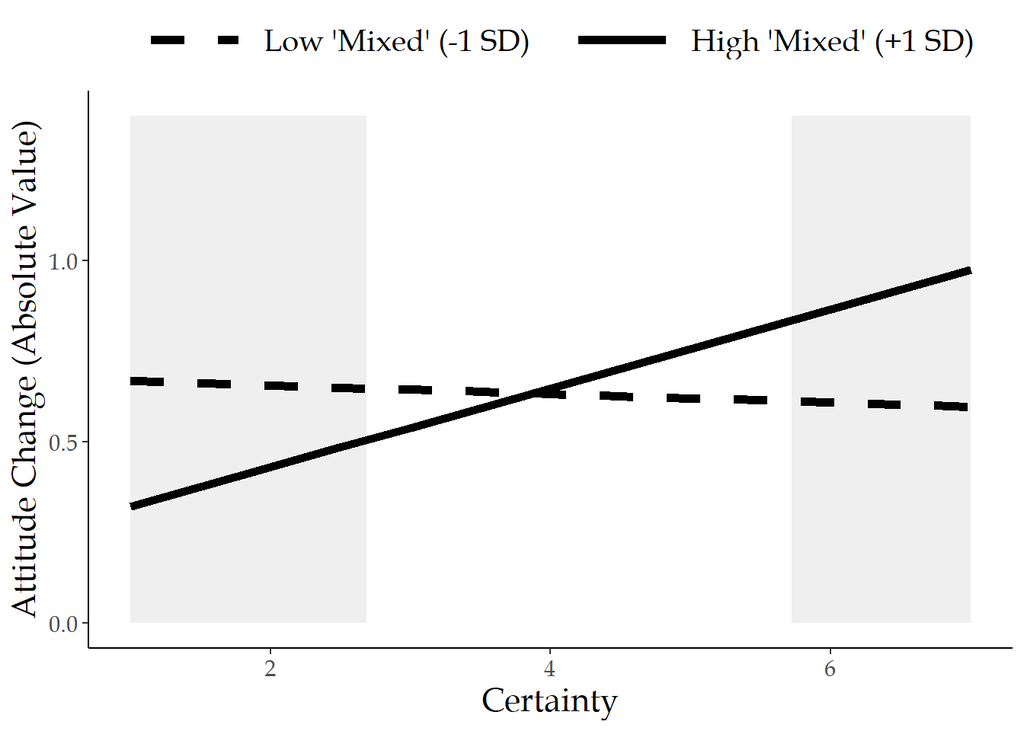

```r
print(figS1)
```

```r
#ggsave(plot = figS1, "FigS1.png", type = "cairo-png", dpi = 600, width = 8, height = 5, units = "in") #Save graph
```

### Using “Conflicted” in place of objective ambivalence

```r
lm(change ~ ex.c + conflicted.c * cert.c, S1) %>% display.lm() %>% kable.lm()
```

| term | B | SE | t | df | p.value | conf.low | conf.high |  |
| --- | --- | --- | --- | --- | --- | --- | --- | --- |
| (Intercept) | 0.59 | 0.04 | 13.23 | 169 | < .001 | 0.50 | 0.67 | *** |
| ex.c | -0.17 | 0.05 | -3.22 | 169 | 0.002 | -0.27 | -0.06 | ** |
| conflicted.c | -0.05 | 0.03 | -1.80 | 169 | 0.074 | -0.11 | 0.01 | . |
| cert.c | 0.05 | 0.03 | 1.38 | 169 | 0.171 | -0.02 | 0.12 |  |
| conflicted.c:cert.c | 0.01 | 0.02 | 0.53 | 169 | 0.596 | -0.03 | 0.05 |  |

## Study 2

```r
S2 <- read_csv("data/Supplement_Study2Data.csv") %>%
  mutate(Date1 = as.Date(Date1, "%m/%d/%Y"),
         Date2 = as.Date(Date2, "%m/%d/%Y"),
         Date3 = as.Date(Date3, "%m/%d/%Y"),
         amb = (neg + pos)/2 - abs(neg - pos),
         attT1 = (att1 + att2 + att3)/3,
         attT2 = (att1_T2 + att2_T2 + att3_T2)/3,
         attT3 = (att1_T3 + att2_T3 + att3_T3)/3,
         change = abs(attT3 - attT1), #Paper focuses on the longer one-year delay
         cert = select(., matches("cert[1-7]")) %>% rowMeans(na.rm = T),
         ex = abs(attT1 - 4))
```

For simplicity, we rename `subj1` as “torn” and `subj3` as “mixed” to highlight the unique items.

```r
S2 <- S2 %>% dplyr::rename(conflicted = subj1, mixed = subj3)
```

Finally, all predictors are mean-centered:

```r
S2 <- S2 %>%
  mutate(ex.c = ex - mean(ex, na.rm = T),
         amb.c = amb - mean(amb, na.rm = T),
         cert.c = cert - mean(cert, na.rm = T),
         mixed.c = mixed - mean(mixed, na.rm = T),
         conflicted.c = conflicted - mean(conflicted, na.rm = T))
```

### Originally Reported Effect

```r
lm(change ~ ex.c + amb.c * cert.c, S2) %>% display.lm() %>% kable.lm()
```

| term | B | SE | t | df | p.value | conf.low | conf.high |  |
| --- | --- | --- | --- | --- | --- | --- | --- | --- |
| (Intercept) | 0.80 | 0.06 | 13.55 | 130 | < .001 | 0.68 | 0.91 | *** |
| ex.c | 0.34 | 0.07 | 4.74 | 130 | < .001 | 0.20 | 0.49 | *** |
| amb.c | 0.03 | 0.04 | 0.74 | 130 | 0.461 | -0.05 | 0.10 |  |
| cert.c | 0.02 | 0.04 | 0.36 | 130 | 0.722 | -0.07 | 0.10 |  |
| amb.c:cert.c | 0.07 | 0.02 | 3.42 | 130 | < .001 | 0.03 | 0.12 | *** |

### Using “Mixed” in place of objective ambivalence

```r
lm(change ~ ex.c + mixed.c * cert.c, S2) %>% display.lm() %>% kable.lm()
```

term

B

SE

t

df

p.value

conf.low

conf.high

(Intercept)

0.82

0.07

11.94

130

< .001

0.69

0.96

***

ex.c

0.28

0.07

3.88

130

< .001

0.14

0.43

***

mixed.c

0.02

0.05

0.37

130

0.71

-0.08

0.11

cert.c

0.00

0.05

0.03

130

0.979

-0.10

0.10

mixed.c:cert.c

0.06

0.03

2.03

130

0.045

0.00

0.11

```r
S2$ex.c <- scale(S2$ex, scale = F) %>% as.vector()
figS2 <- ggeffect(lm(change ~ ex.c + mixed * cert, S2),
         terms = c("cert", "mixed [meansd]")) %>%
  mutate(mixed = factor(group, labels = c("Low 'Mixed' (-1 SD)   ",
                                          "Mean Ambivalence",
                                          "High 'Mixed' (+1 SD)"))) %>%
  filter(mixed != "Mean Ambivalence") %>%
  ggplot(aes(x = x, y = predicted, linetype = mixed)) +
  annotate(geom = "rect", xmin = min(S2$cert, na.rm = T),
           xmax = mean(S2$cert, na.rm = T) - sd(S2$cert, na.rm = T),
           ymin = 0, ymax = 1.4, fill = "grey", alpha = 0.25) +
    annotate(geom = "rect", xmin = mean(S2$cert, na.rm = T) + sd(S2$cert, na.rm = T),
           xmax = max(S2$cert, na.rm = T),
           ymin = 0, ymax = 1.4, fill = "grey", alpha = 0.25) +
  geom_line(size = 2) +
  apatheme +
  labs(y = "Attitude Change (Absolute Value)",
       x = "Certainty",
       linetype = "") +
  scale_linetype_manual(values = c("dashed", "solid")) +
  guides(fill = F, color = F,
         linetype = guide_legend(keywidth = 0.75, default.unit = "inch")) +
  theme(legend.position = "top",
        text = element_text(size = 14, family = "Book Antiqua"),
        axis.title.x = element_text(size = 16),
        axis.title.y = element_text(size = 16),
        legend.text = element_text(size = 15)) +
  ylim(c(0,1.4))
```

```
## Package `effects` is not available, but needed for `ggeffect()`. Either install package `effects`, or use `ggpredict()`. Calling `ggpredict()` now.FALSE
```

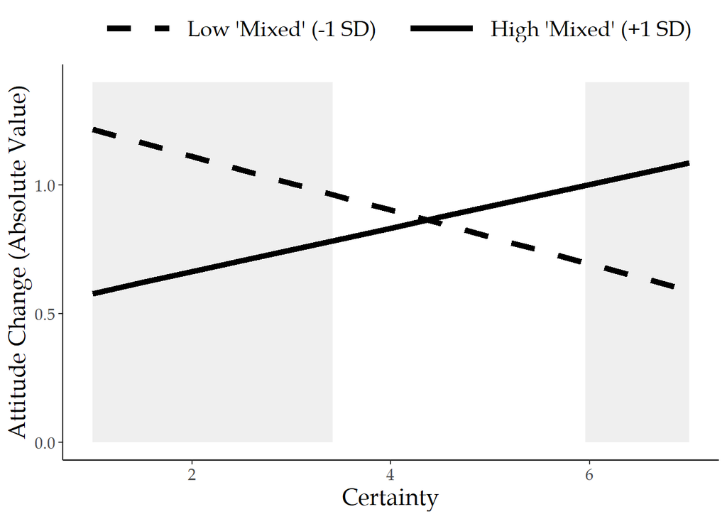

```r
print(figS2)
```

```r
#ggsave(plot = figS2, "FigS2.png", type = "cairo-png", dpi = 600, width = 8, height = 5, units = "in") #Save graph
```

### Using “Conflicted” in place of objective ambivalence:

```r
lm(change ~ ex.c + conflicted.c * cert.c, S2) %>% display.lm() %>% kable.lm()
```

| term | B | SE | t | df | p.value | conf.low | conf.high |  |
| --- | --- | --- | --- | --- | --- | --- | --- | --- |
| (Intercept) | 0.79 | 0.07 | 11.76 | 130 | < .001 | 0.66 | 0.92 | *** |
| ex.c | 0.27 | 0.07 | 3.81 | 130 | < .001 | 0.13 | 0.41 | *** |
| conflicted.c | 0.02 | 0.04 | 0.35 | 130 | 0.724 | -0.07 | 0.10 |  |
| cert.c | 0.00 | 0.05 | -0.07 | 130 | 0.948 | -0.10 | 0.09 |  |
| conflicted.c:cert.c | 0.03 | 0.03 | 1.25 | 130 | 0.215 | -0.02 | 0.08 |  |

# Supplemental Analysis: Main Effects Models

## Main Study (Table S2)

**“Mixed”: Any Change**

```r
glm(change ~ Age + Gender.dum + Education + Ideology + mixed.c + cert.c,
    family = "binomial", df.sub) %>%  display.glm() %>% kable.lm()
```

term

B

SE

Z

df

p.value

conf.low

conf.high

(Intercept)

-0.60

1.00

-0.60

361

0.551

-2.57

1.36

Age

0.01

0.01

1.48

361

0.139

0.00

0.03

Gender.dum

0.28

0.25

1.12

361

0.261

-0.21

0.77

Education

-0.11

0.05

-2.16

361

0.031

-0.21

-0.01

Ideology

0.02

0.08

0.21

361

0.832

-0.13

0.17

mixed.c

0.28

0.08

3.24

361

0.001

0.11

0.45

cert.c

-0.04

0.10

-0.38

361

0.701

-0.23

0.16

**“Mixed”: Strict Change**

```r
glm(change_strict ~ Age + Gender.dum + Education + Ideology + mixed.c + cert.c,
    family = "binomial", df.strict) %>%  display.glm() %>% kable.lm()
```

term

B

SE

Z

df

p.value

conf.low

conf.high

(Intercept)

-2.34

1.41

-1.66

303

0.097

-5.17

0.37

.

Age

0.03

0.01

2.07

303

0.039

0.00

0.05

Gender.dum

0.36

0.35

1.03

303

0.305

-0.33

1.06

Education

-0.09

0.07

-1.35

303

0.178

-0.22

0.04

Ideology

-0.03

0.10

-0.25

303

0.806

-0.23

0.18

mixed.c

0.14

0.12

1.24

303

0.214

-0.08

0.38

cert.c

-0.06

0.13

-0.44

303

0.66

-0.32

0.21

**“Torn”: Any Change**

```r
glm(change ~ Age + Gender.dum + Education + Ideology + torn.c + cert.c,
    family = "binomial", df.sub) %>%  display.glm() %>% kable.lm()
```

term

B

SE

Z

df

p.value

conf.low

conf.high

(Intercept)

-0.64

1.05

-0.61

353

0.543

-2.70

1.41

Age

0.01

0.01

1.48

353

0.138

0.00

0.03

Gender.dum

0.26

0.26

0.99

353

0.323

-0.25

0.77

Education

-0.13

0.05

-2.37

353

0.018

-0.24

-0.02

Ideology

0.07

0.08

0.85

353

0.397

-0.09

0.23

torn.c

0.24

0.05

4.68

353

< .001

0.14

0.34

***

cert.c

-0.04

0.10

-0.44

353

0.659

-0.23

0.15

**“Torn”: Strict Change**

```r
glm(change_strict ~ Age + Gender.dum + Education + Ideology + torn.c + cert.c,
    family = "binomial", df.strict) %>%  display.glm() %>% kable.lm()
```

term

B

SE

Z

df

p.value

conf.low

conf.high

(Intercept)

-2.53

1.47

-1.72

297

0.085

-5.49

0.30

.

Age

0.03

0.01

2.05

297

0.041

0.00

0.05

Gender.dum

0.30

0.36

0.83

297

0.407

-0.41

1.02

Education

-0.09

0.07

-1.30

297

0.192

-0.24

0.05

Ideology

0.01

0.11

0.12

297

0.906

-0.20

0.23

torn.c

0.17

0.07

2.31

297

0.021

0.03

0.31

cert.c

-0.08

0.13

-0.61

297

0.54

-0.33

0.18

## Re-Analyses (Table S3)

### Study 1

**Objective Ambivalence**

```r
lm(change ~ ex.c + amb.c + cert.c, S1) %>% display.lm() %>% kable.lm()
```

| term | B | SE | t | df | p.value | conf.low | conf.high |  |
| --- | --- | --- | --- | --- | --- | --- | --- | --- |
| (Intercept) | 0.59 | 0.04 | 13.18 | 170 | < .001 | 0.50 | 0.67 | *** |
| ex.c | -0.17 | 0.06 | -2.97 | 170 | 0.003 | -0.28 | -0.06 | ** |
| amb.c | -0.03 | 0.03 | -0.97 | 170 | 0.336 | -0.09 | 0.03 |  |
| cert.c | 0.03 | 0.03 | 1.02 | 170 | 0.31 | -0.03 | 0.10 |  |

**Mixed**

```r
lm(change ~ ex.c + mixed.c + cert.c, S1) %>% display.lm() %>% kable.lm()
```

| term | B | SE | t | df | p.value | conf.low | conf.high |  |
| --- | --- | --- | --- | --- | --- | --- | --- | --- |
| (Intercept) | 0.59 | 0.04 | 13.27 | 170 | < .001 | 0.50 | 0.68 | *** |
| ex.c | -0.14 | 0.05 | -2.75 | 170 | 0.007 | -0.25 | -0.04 | ** |
| mixed.c | 0.00 | 0.03 | -0.06 | 170 | 0.951 | -0.07 | 0.06 |  |
| cert.c | 0.04 | 0.04 | 1.08 | 170 | 0.281 | -0.03 | 0.11 |  |

**Conflicted**

```r
lm(change ~ ex.c + conflicted.c + cert.c, S1) %>% display.lm() %>% kable.lm()
```

| term | B | SE | t | df | p.value | conf.low | conf.high |  |
| --- | --- | --- | --- | --- | --- | --- | --- | --- |
| (Intercept) | 0.58 | 0.04 | 13.27 | 170 | < .001 | 0.50 | 0.67 | *** |
| ex.c | -0.17 | 0.05 | -3.30 | 170 | 0.001 | -0.27 | -0.07 | ** |
| conflicted.c | -0.06 | 0.03 | -1.94 | 170 | 0.054 | -0.11 | 0.00 | . |
| cert.c | 0.04 | 0.03 | 1.29 | 170 | 0.197 | -0.02 | 0.11 |  |

### Study 2

**Objective Ambivalence**

```r
lm(change ~ ex.c + amb.c + cert.c, S2) %>% display.lm() %>% kable.lm()
```

| term | B | SE | t | df | p.value | conf.low | conf.high |  |
| --- | --- | --- | --- | --- | --- | --- | --- | --- |
| (Intercept) | 0.76 | 0.06 | 12.65 | 131 | < .001 | 0.64 | 0.88 | *** |
| ex.c | 0.31 | 0.07 | 4.21 | 131 | < .001 | 0.17 | 0.46 | *** |
| amb.c | 0.06 | 0.04 | 1.56 | 131 | 0.121 | -0.02 | 0.13 |  |
| cert.c | 0.00 | 0.05 | 0.01 | 131 | 0.993 | -0.09 | 0.09 |  |

**Mixed**

```r
lm(change ~ ex.c + mixed.c + cert.c, S2) %>% display.lm() %>% kable.lm()
```

| term | B | SE | t | df | p.value | conf.low | conf.high |  |
| --- | --- | --- | --- | --- | --- | --- | --- | --- |
| (Intercept) | 0.76 | 0.06 | 12.41 | 131 | < .001 | 0.63 | 0.88 | *** |
| ex.c | 0.25 | 0.07 | 3.51 | 131 | < .001 | 0.11 | 0.40 | *** |
| mixed.c | 0.00 | 0.05 | -0.02 | 131 | 0.983 | -0.09 | 0.09 |  |
| cert.c | -0.01 | 0.05 | -0.11 | 131 | 0.91 | -0.11 | 0.10 |  |

**Conflicted**

```r
lm(change ~ ex.c + conflicted.c + cert.c, S2) %>% display.lm() %>% kable.lm()
```

| term | B | SE | t | df | p.value | conf.low | conf.high |  |
| --- | --- | --- | --- | --- | --- | --- | --- | --- |
| (Intercept) | 0.75 | 0.06 | 12.41 | 131 | < .001 | 0.63 | 0.88 | *** |
| ex.c | 0.25 | 0.07 | 3.65 | 131 | < .001 | 0.12 | 0.39 | *** |
| conflicted.c | 0.00 | 0.04 | -0.07 | 131 | 0.942 | -0.09 | 0.08 |  |
| cert.c | -0.01 | 0.05 | -0.14 | 131 | 0.892 | -0.10 | 0.09 |  |

# Supplemental Analysis: Models without Covariates

**“Mixed”: Any Change**

```r
glm(change ~ mixed.c * cert.c, family = "binomial", df.sub) %>%
  display.glm() %>% kable.lm()
```

| term | B | SE | Z | df | p.value | conf.low | conf.high |  |
| --- | --- | --- | --- | --- | --- | --- | --- | --- |
| (Intercept) | -1.07 | 0.13 | -8.45 | 378 | < .001 | -1.33 | -0.83 | *** |
| mixed.c | 0.26 | 0.08 | 3.26 | 378 | 0.001 | 0.10 | 0.42 | ** |
| cert.c | -0.13 | 0.10 | -1.36 | 378 | 0.175 | -0.32 | 0.06 |  |
| mixed.c:cert.c | 0.15 | 0.06 | 2.65 | 378 | 0.008 | 0.04 | 0.26 | ** |

**“Mixed”: Strict Change**

```r
glm(change_strict ~ mixed.c * cert.c, family = "binomial", df.strict) %>%
  display.glm() %>% kable.lm()
```

term

B

SE

Z

df

p.value

conf.low

conf.high

(Intercept)

-1.93

0.18

-10.77

316

< .001

-2.30

-1.60

***

mixed.c

0.16

0.11

1.49

316

0.136

-0.05

0.38

cert.c

-0.18

0.13

-1.37

316

0.172

-0.44

0.09

mixed.c:cert.c

0.16

0.08

2.12

316

0.034

0.01

0.31

**“Torn”: Any Change**

```r
glm(change ~ torn.c * cert.c, family = "binomial", df.sub) %>%
  display.glm() %>% kable.lm()
```

| term | B | SE | Z | df | p.value | conf.low | conf.high |  |
| --- | --- | --- | --- | --- | --- | --- | --- | --- |
| (Intercept) | -1.19 | 0.13 | -9.14 | 369 | < .001 | -1.45 | -0.94 | *** |
| torn.c | 0.21 | 0.05 | 4.33 | 369 | < .001 | 0.11 | 0.30 | *** |
| cert.c | -0.10 | 0.10 | -1.03 | 369 | 0.301 | -0.28 | 0.09 |  |
| torn.c:cert.c | 0.04 | 0.03 | 1.23 | 369 | 0.22 | -0.03 | 0.11 |  |

**“Torn”: Strict Change**

```r
glm(change_strict ~ torn.c * cert.c, family = "binomial", df.strict) %>%
  display.glm() %>% kable.lm()
```

term

B

SE

Z

df

p.value

conf.low

conf.high

(Intercept)

-2.06

0.19

-10.96

310

< .001

-2.45

-1.71

***

torn.c

0.16

0.07

2.28

310

0.022

0.02

0.29

cert.c

-0.18

0.13

-1.35

310

0.176

-0.43

0.09

torn.c:cert.c

0.08

0.05

1.64

310

0.102

-0.02

0.18